# entregable_1

Ruben Castillo y Manuel Rubio

2023-11-28

## Ejercicio 1

Considera la variable respuesta Price relacionandola con la variable X con la que tenga mayor relación lineal

```r
cars <- read.csv2("cars.csv")
```

```r
cor(subset(cars,select = c(-Type,-Origin)))["Price",]
```

```
##              Price           MPG.city        MPG.highway         EngineSize
##        1.000000000       -0.594562163       -0.560680362        0.597425392
##         Horsepower                RPM       Rev.per.mile Fuel.tank.capacity
##        0.788217578       -0.004954931       -0.426395113        0.619479981
##         Passengers             Length          Wheelbase              Width
##        0.057860074        0.503628440        0.500864163        0.456027866
##             Weight
##        0.647179005
```

Con esto se tiene que la variable con la que tiene mayor relacion lineal es Horsepower

- Evalúa el efecto de X sobre Price.

```r
cor.test(cars$Price,cars$Horsepower)
```

```
##
##  Pearson's product-moment correlation
##
## data:  cars$Price and cars$Horsepower
## t = 12.218, df = 91, p-value < 2.2e-16
## alternative hypothesis: true correlation is not equal to 0
## 95 percent confidence interval:
##  0.6963140 0.8546911
## sample estimates:
##       cor
## 0.7882176
```

Es una relación lineal positiva, lo que implica que a mayor horsepower mayor es el precio

- Obtén la recta mínimos cuadrados. Interpreta los resultados obtenidos (coeficientes, significatividad, R2, contraste del modelo, etc…).

```r
reg <- lm(Price ~ Horsepower, data=cars)
summary(reg)
```

```
##
## Call:
## lm(formula = Price ~ Horsepower, data = cars)
##
## Residuals:
##     Min      1Q  Median      3Q     Max
## -16.413  -2.792  -0.821   1.803  31.753
##
## Coefficients:
##             Estimate Std. Error t value Pr(>|t|)
## (Intercept)  -1.3988     1.8200  -0.769    0.444
## Horsepower    0.1454     0.0119  12.218   <2e-16 ***
## ---
## Signif. codes:  0 '***' 0.001 '**' 0.01 '*' 0.05 '.' 0.1 ' ' 1
##
## Residual standard error: 5.977 on 91 degrees of freedom
## Multiple R-squared:  0.6213, Adjusted R-squared:  0.6171
## F-statistic: 149.3 on 1 and 91 DF,  p-value: < 2.2e-16
```

En cuanto al valor de R squared, se tiene que es de 0.62, que indica la capacidad de ajuste para la variable Precio usando unicamente la variable Horsepower.

Si se representa graficamente, se puede observar el comportamiento anterior

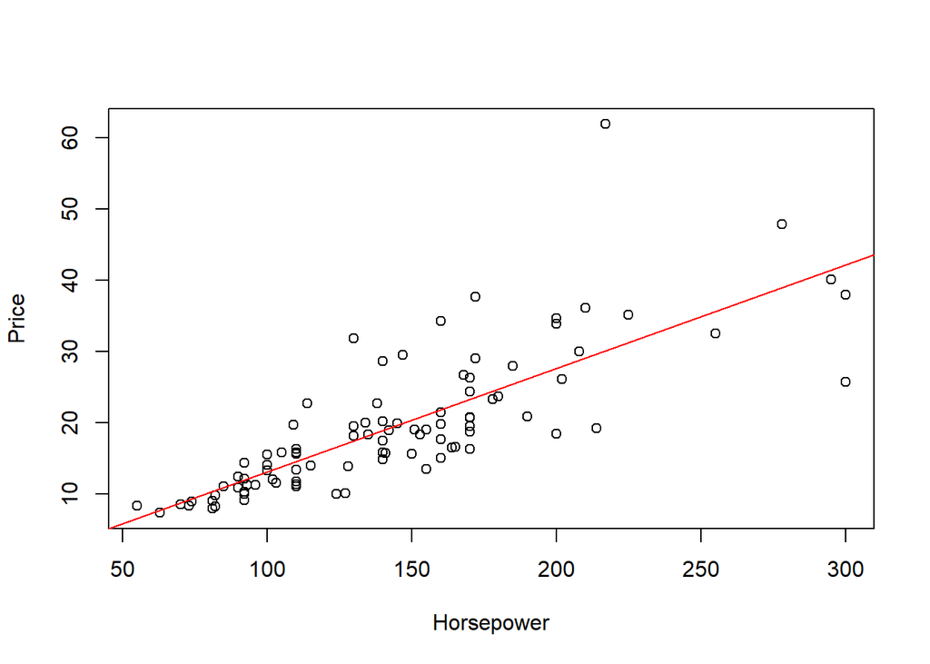

```r
with(cars,plot(Horsepower,Price))
abline(coef=coefficients(reg),col='RED')
```

- Dibuja el diagrama de dispersión, la recta de regresión y las bandas de confianza al 90 %.

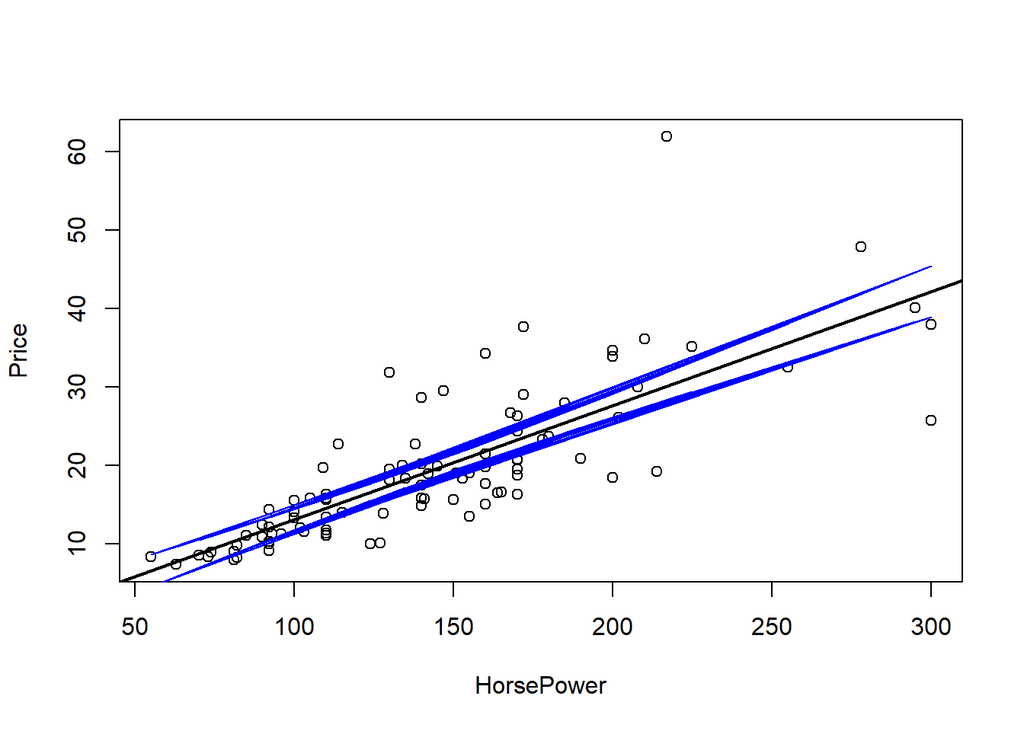

```r
plot(cars$Horsepower,cars$Price,xlab='HorsePower',ylab='Price')
abline(coef = coefficients(reg), lwd=2)
df <- data.frame(list(Horsepower=cars$Horsepower))
bandas <- predict(reg, newdata = df, interval = "confidence",level = 0.9)
lines(cars$Horsepower,bandas[,2],col='BLUE')
lines(cars$Horsepower,bandas[,3],col='BLUE')
```

- Realiza un diagnóstico de los residuos. Si falla algunas de las condiciones, busca una posible solución.

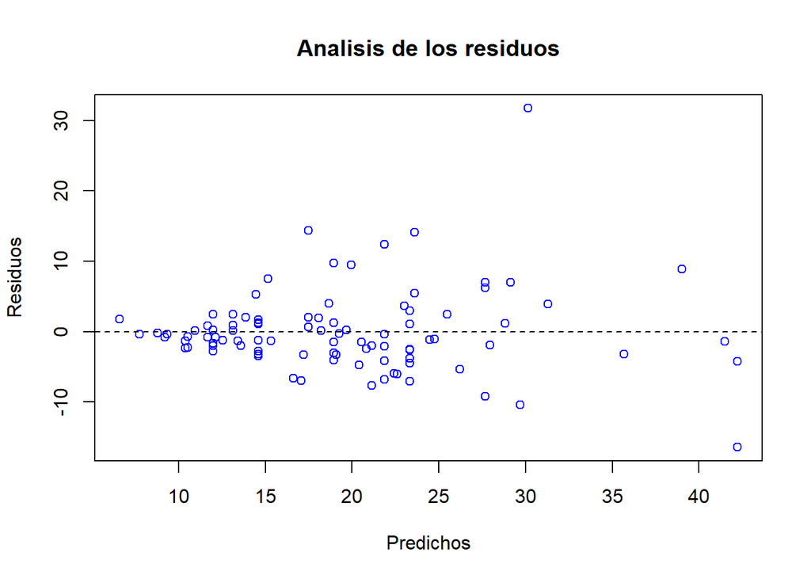

```r
plot(reg$fitted.values,reg$residuals, col='BLUE',
     xlab = 'Predichos',ylab = 'Residuos', main = 'Analisis de los residuos')
abline(h=0,lty=2)
```

```r
#aquí le he metido todos los test que tenemos que hacer (heterocedasticidad, media cero y que sea normal)

mean(reg$residuals)
```

```
## [1] 1.314543e-16
```

```r
shapiro.test(reg$residuals)
```

```
##
##  Shapiro-Wilk normality test
##
## data:  reg$residuals
## W = 0.859, p-value = 6.113e-08
```

Se puede observar que la media de los residuos es 0, condición que se da de forma matemática. Pero presentan heterocedasticidad, a la vez que el saphiro test indica que no siguen una distribución normal.

Como solución se propone aplicar una transformación a la variable horsepower, en este caso en primer lugar se prueba aplicando el logaritmo

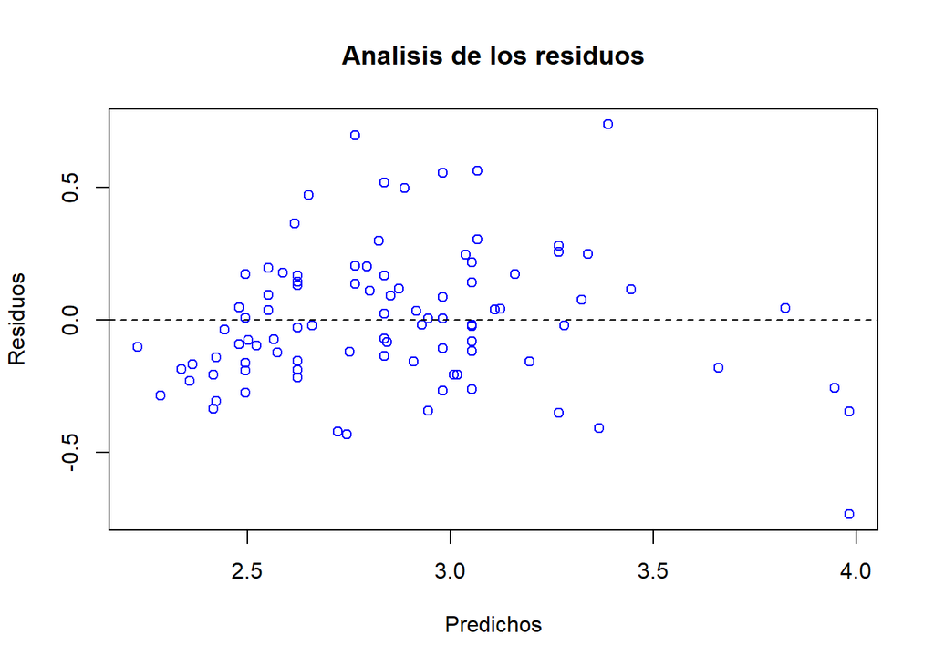

```r
reg <- lm(log(Price) ~ Horsepower, data=cars)
plot(reg$fitted.values,reg$residuals, col='BLUE',
     xlab = 'Predichos',ylab = 'Residuos', main = 'Analisis de los residuos')
abline(h=0,lty=2)
```

Esta transformación, como se observa en la gráfica, es capaz de eliminar la heterocedasticidad.

Ahora vamos a comprobar que sigue una distribución normal:

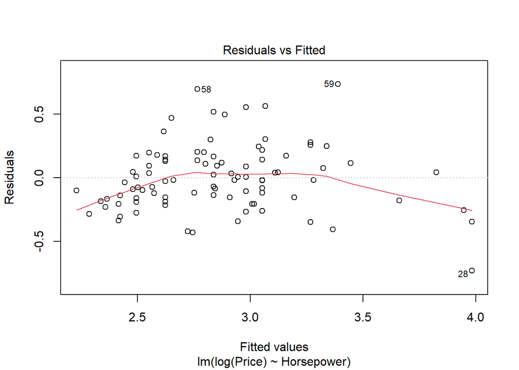

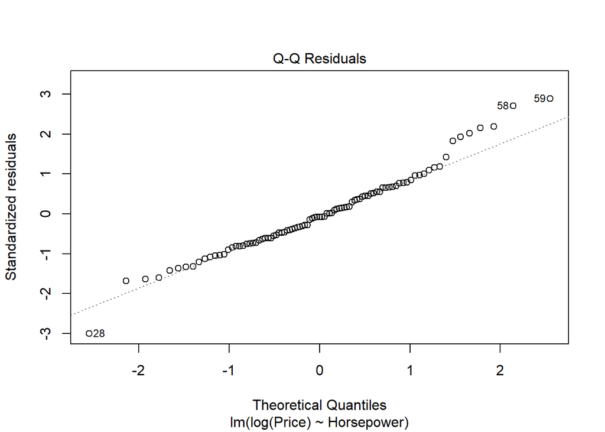

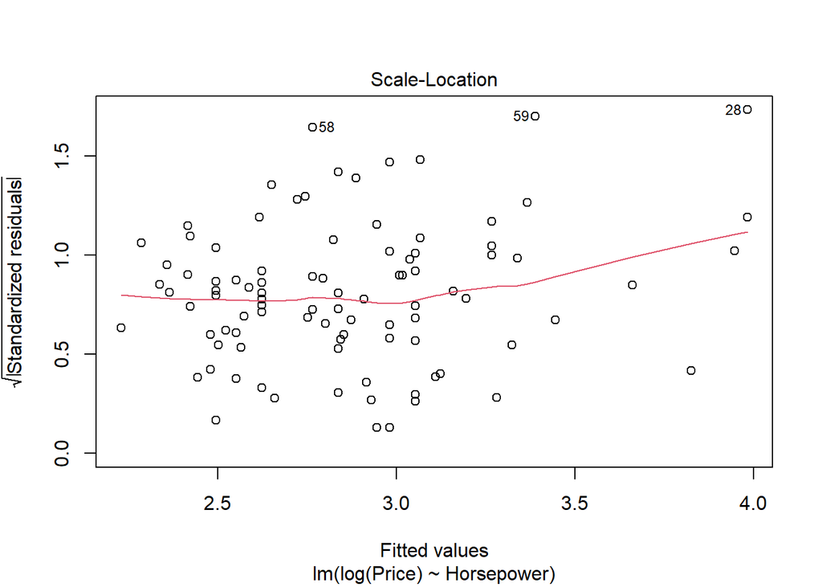

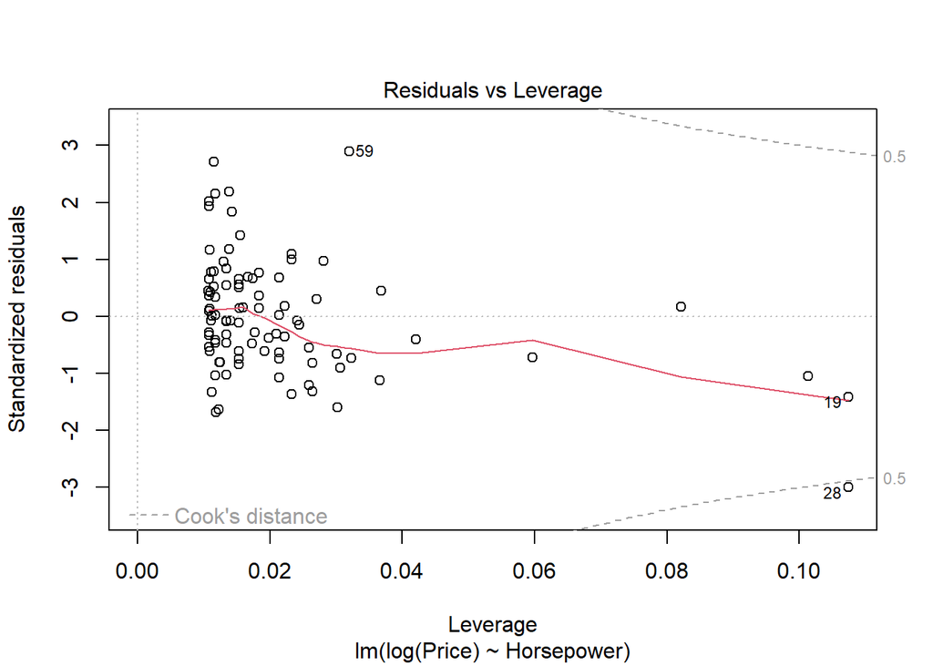

```r
plot(reg)
```

```r
shapiro.test(reg$residuals)
```

```
##
##  Shapiro-Wilk normality test
##
## data:  reg$residuals
## W = 0.97667, p-value = 0.0942
```

Con esto conseguimos normalizar de forma considerable los residuos, pero con un valor rozando el limite de confianza. Por último, quitaría esos 3 outliers que aparecen para terminar de ajustar bien estos.

Antes de eliminarlos, se estudian las posibles causas de su valor para determinar si son coherentes

```r
print("\nOutlier numero 1")
```

```
## [1] "\nOutlier numero 1"
```

```r
print(cars[28,])
```

```
##      Type Price MPG.city MPG.highway EngineSize Horsepower  RPM Rev.per.mile
## 28 Sporty  25.8       18          24          3        300 6000         2120
##    Fuel.tank.capacity Passengers Length Wheelbase Width Weight Origin
## 28               19.8          4    180        97    72   3805    USA
```

```r
print("\nOutlier numero 2")
```

```
## [1] "\nOutlier numero 2"
```

```r
print(cars[58,])
```

```
##       Type Price MPG.city MPG.highway EngineSize Horsepower  RPM Rev.per.mile
## 58 Compact  31.9       20          29        2.3        130 5100         2425
##    Fuel.tank.capacity Passengers Length Wheelbase Width Weight  Origin
## 58               14.5          5    175       105    67   2920 non-USA
```

```r
print("\nOutlier numero 3")
```

```
## [1] "\nOutlier numero 3"
```

```r
print(cars[59,])
```

```
##       Type Price MPG.city MPG.highway EngineSize Horsepower  RPM Rev.per.mile
## 59 Midsize  61.9       19          25        3.2        217 5500         2220
##    Fuel.tank.capacity Passengers Length Wheelbase Width Weight  Origin
## 59               18.5          5    187       110    69   3525 non-USA
```

Estos es posible que sean correctos, siendo la información proporcionada por otras variables importante de cara a la predicción del precio en el modelo. Para que no afecte a nuestro modelo, se eliminan estos datos.

```r
cars_m1 <- cars[c(-28,-58,-59),]
```

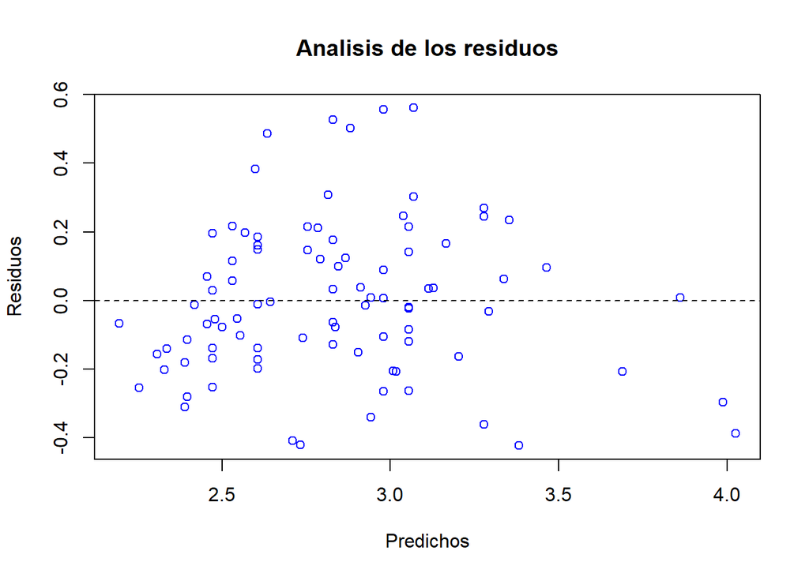

```r
reg <- lm(log(Price) ~ Horsepower, data=cars_m1)
plot(reg$fitted.values,reg$residuals, col='BLUE',
     xlab = 'Predichos',ylab = 'Residuos', main = 'Analisis de los residuos')
abline(h=0,lty=2)
```

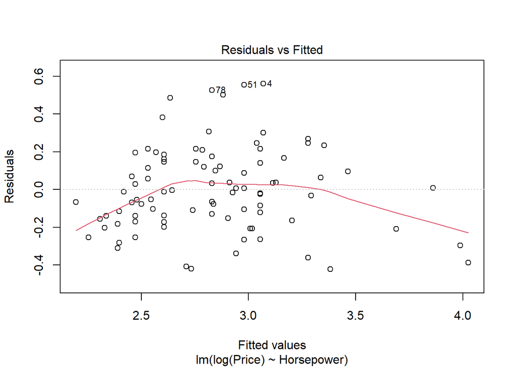

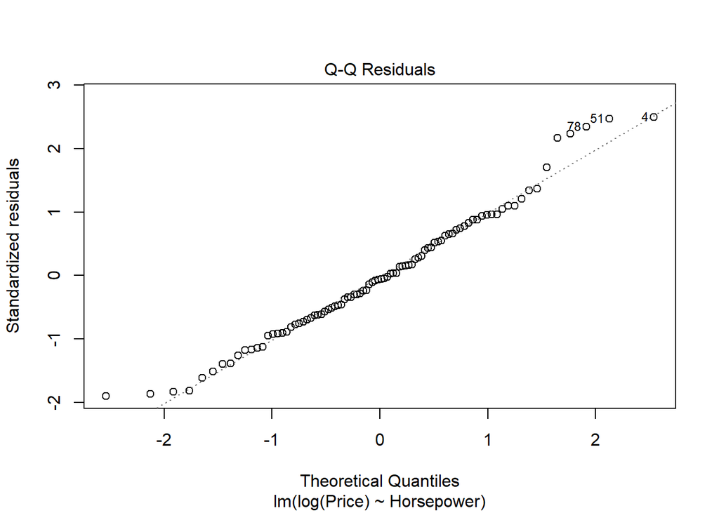

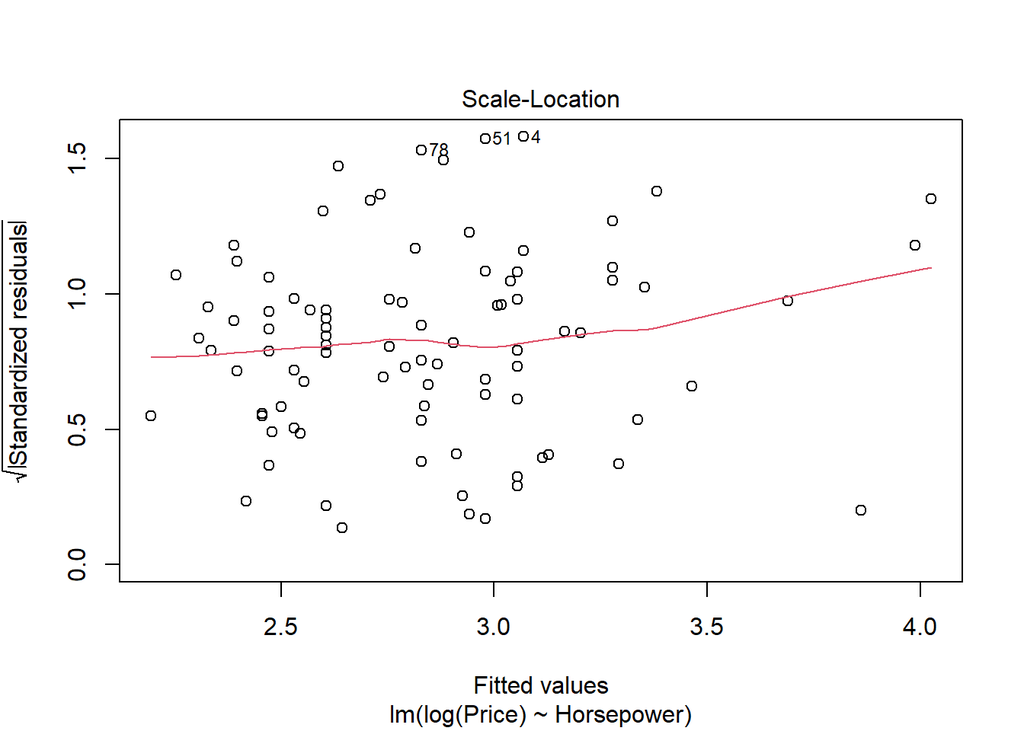

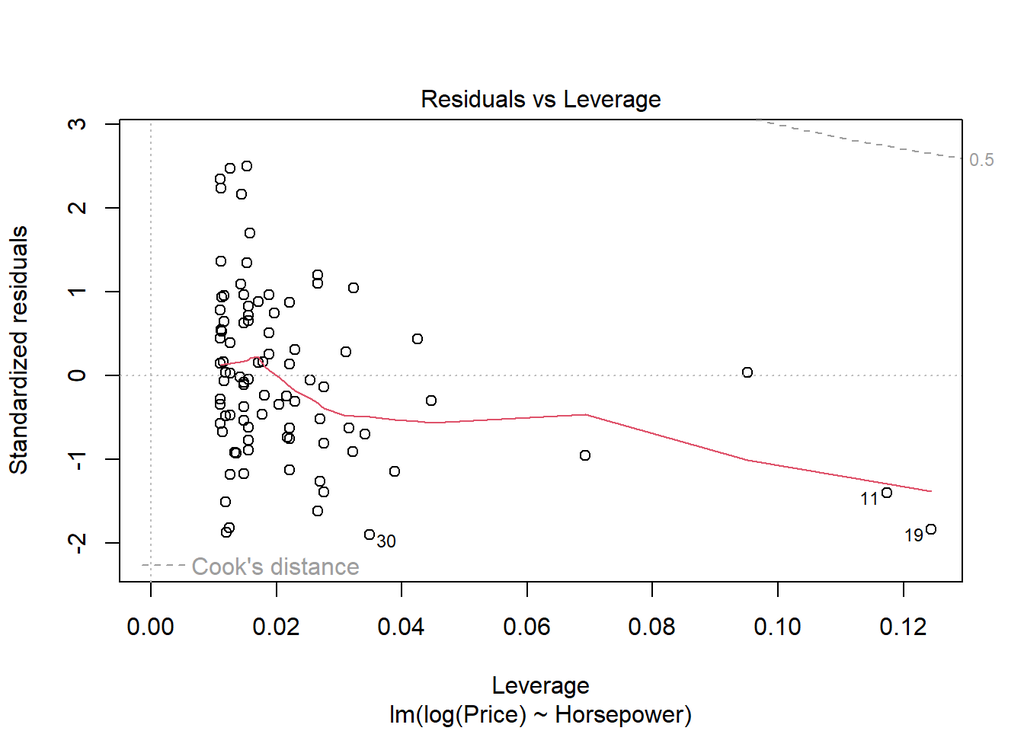

```r
plot(reg)
```

```r
shapiro.test(reg$residuals)
```

```
##
##  Shapiro-Wilk normality test
##
## data:  reg$residuals
## W = 0.97822, p-value = 0.1354
```

Se obtiene que ahora, de acuerdo con el shapiro test la confianza es mayor para determinar que los errores siguen una muestra normal

## Ejercicio 2

Considera la variable respuesta Price relacionandola con el predictor MPG.city.

- Evalúa el efecto de MPG.city sobre Price

```r
reg <- lm(Price ~ MPG.city, data=cars)
cor(cars$MPG.city,cars$Price)
```

```
## [1] -0.5945622
```

Se puede observar que es una relación más o menos a priori inversamente lineal, donde el valor mayor de city decrementa el precio

- Obtén la recta mínimos cuadrados. Interpreta los resultados obtenidos (coeficientes, significatividad, R2, contraste del modelo, etc…).

```r
reg <- lm(Price ~ MPG.city, data=cars)
summary(reg)
```

```
##
## Call:
## lm(formula = Price ~ MPG.city, data = cars)
##
## Residuals:
##     Min      1Q  Median      3Q     Max
## -10.437  -4.871  -2.152   1.961  38.951
##
## Coefficients:
##             Estimate Std. Error t value Pr(>|t|)
## (Intercept)  42.3661     3.3399  12.685  < 2e-16 ***
## MPG.city     -1.0219     0.1449  -7.054 3.31e-10 ***
## ---
## Signif. codes:  0 '***' 0.001 '**' 0.01 '*' 0.05 '.' 0.1 ' ' 1
##
## Residual standard error: 7.809 on 91 degrees of freedom
## Multiple R-squared:  0.3535, Adjusted R-squared:  0.3464
## F-statistic: 49.76 on 1 and 91 DF,  p-value: 3.308e-10
```

Se puede observar que el valor de MPG.city es significativo, ya que además de su pvalor es regresión lineal univariada.

Además se tiene que el modelo es capaz de explicar en un 35% los datos, según su R squared.

Esto se puede observar representandolo graficamente, donde se tiene una recta que no se ajusta en gran medida a los datos.

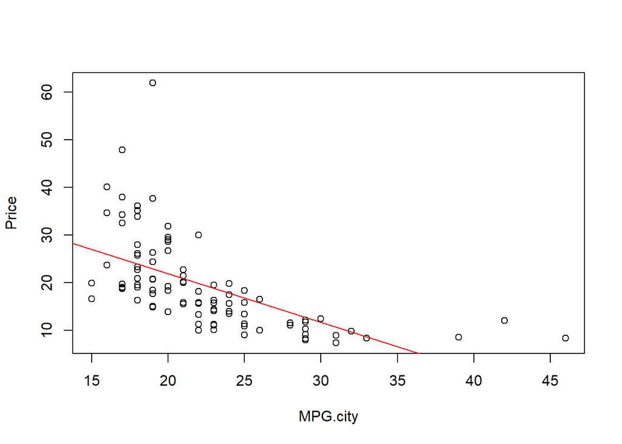

```r
with(cars,plot(MPG.city,Price))
abline(coef=coefficients(reg),col='RED')
```

[figure not shown]

```r
plot(cars$MPG.city,cars$Price,xlab='HorsePower',ylab='Price')
abline(coef = coefficients(reg), lwd=2)
df <- data.frame(list(MPG.city=cars$MPG.city))
bandas <- predict(reg, newdata = df, interval = "confidence",level = 0.9)
lines(cars$MPG.city,bandas[,2],col='BLUE')
lines(cars$MPG.city,bandas[,3],col='BLUE')
```

- Realiza un análisis de los residuos.

Con el modelo anterior, los residuos se obtienen de la forma

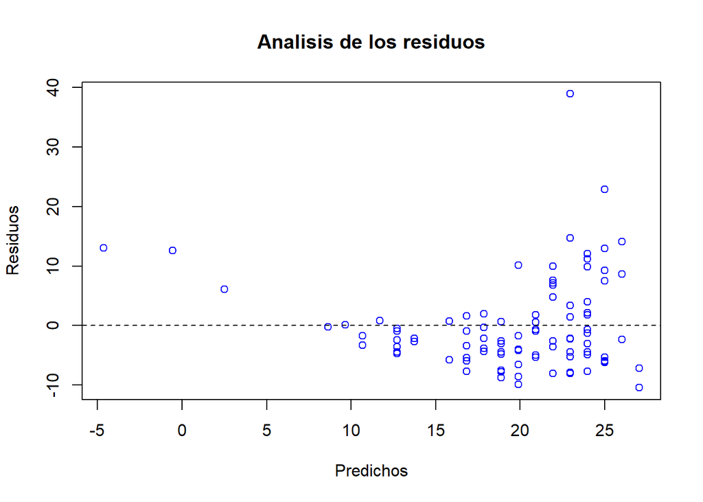

```r
plot(reg$fitted.values,reg$residuals, col='BLUE',
     xlab = 'Predichos',ylab = 'Residuos', main = 'Analisis de los residuos')
abline(h=0,lty=2)
```

```r
residuos <- residuals(reg)
summary(residuos)
```

```
##    Min. 1st Qu.  Median    Mean 3rd Qu.    Max.
## -10.437  -4.871  -2.152   0.000   1.961  38.951
```

Los residuos, como era de esperar quedan centrados en el 0. En este caso parece que existe algo de heterocedasticidad, en especial en los extremos, al estar los valores del centro más pegados a la media.

- ```
  ¿Te parece adecuado haber realizado regresión lineal o es preferible otro tipo de regresión?. Ajusta el modelo que te parezca más adecuado.
  ```

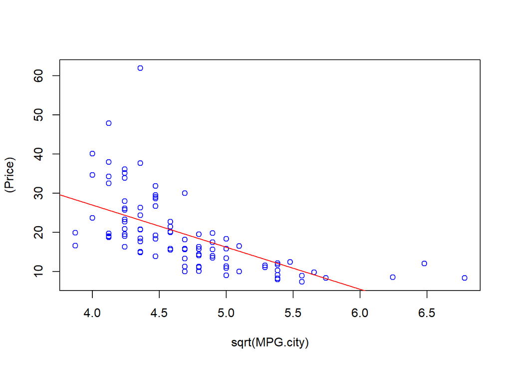

```r
regre <- lm(Price ~ sqrt(MPG.city), data=cars)
with(cars,plot(sqrt(MPG.city),(Price),col='BLUE'))
abline(coef=coefficients(regre),col='RED')
```

```r
residuos <- residuals(regre)
summary(residuos)
```

```
##    Min. 1st Qu.  Median    Mean 3rd Qu.    Max.
## -11.750  -4.858  -1.825   0.000   2.142  38.764
```

```r
print("Modelo sin transformación")
```

```
## [1] "Modelo sin transformación"
```

```r
summary(reg)
```

```
##
## Call:
## lm(formula = Price ~ MPG.city, data = cars)
##
## Residuals:
##     Min      1Q  Median      3Q     Max
## -10.437  -4.871  -2.152   1.961  38.951
##
## Coefficients:
##             Estimate Std. Error t value Pr(>|t|)
## (Intercept)  42.3661     3.3399  12.685  < 2e-16 ***
## MPG.city     -1.0219     0.1449  -7.054 3.31e-10 ***
## ---
## Signif. codes:  0 '***' 0.001 '**' 0.01 '*' 0.05 '.' 0.1 ' ' 1
##
## Residual standard error: 7.809 on 91 degrees of freedom
## Multiple R-squared:  0.3535, Adjusted R-squared:  0.3464
## F-statistic: 49.76 on 1 and 91 DF,  p-value: 3.308e-10
```

```r
print("\nModelo con transformación")
```

```
## [1] "\nModelo con transformación"
```

```r
summary(regre)
```

```
##
## Call:
## lm(formula = Price ~ sqrt(MPG.city), data = cars)
##
## Residuals:
##     Min      1Q  Median      3Q     Max
## -11.750  -4.858  -1.825   2.142  38.764
##
## Coefficients:
##                Estimate Std. Error t value Pr(>|t|)
## (Intercept)      69.905      6.796  10.287  < 2e-16 ***
## sqrt(MPG.city)  -10.729      1.437  -7.467 4.79e-11 ***
## ---
## Signif. codes:  0 '***' 0.001 '**' 0.01 '*' 0.05 '.' 0.1 ' ' 1
##
## Residual standard error: 7.648 on 91 degrees of freedom
## Multiple R-squared:  0.3799, Adjusted R-squared:  0.3731
## F-statistic: 55.76 on 1 and 91 DF,  p-value: 4.791e-11
```

Se prueba con otro tipo de transformacion, que ajuste en mejor medida los datos

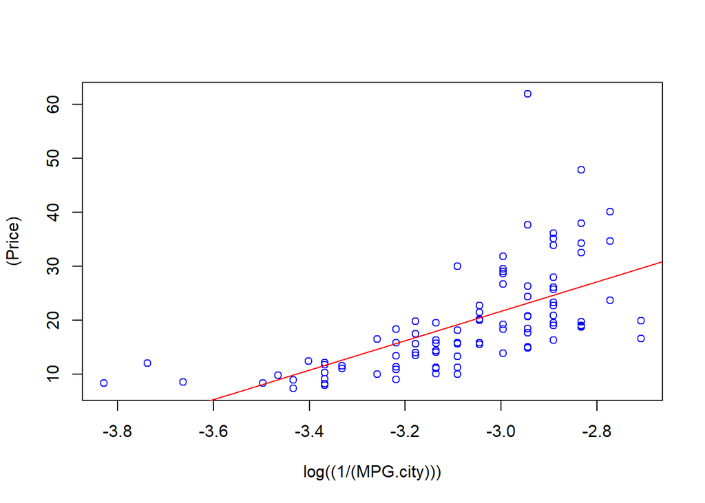

```r
regre <- lm(Price ~ log((1/(MPG.city))), data=cars)
with(cars,plot(log((1/(MPG.city))),(Price),col='BLUE'))
abline(coef=coefficients(regre),col='RED')
```

```r
print("\nModelo con transformación")
```

```
## [1] "\nModelo con transformación"
```

```r
summary(regre)
```

```
##
## Call:
## lm(formula = Price ~ log((1/(MPG.city))), data = cars)
##
## Residuals:
##     Min      1Q  Median      3Q     Max
## -13.081  -4.679  -1.558   2.651  38.666
##
## Coefficients:
##                     Estimate Std. Error t value Pr(>|t|)
## (Intercept)          103.543     10.825   9.565 2.07e-15 ***
## log((1/(MPG.city)))   27.275      3.504   7.783 1.07e-11 ***
## ---
## Signif. codes:  0 '***' 0.001 '**' 0.01 '*' 0.05 '.' 0.1 ' ' 1
##
## Residual standard error: 7.525 on 91 degrees of freedom
## Multiple R-squared:  0.3997, Adjusted R-squared:  0.3931
## F-statistic: 60.58 on 1 and 91 DF,  p-value: 1.073e-11
```

Se tiene que este modelo tiene mayor caracter explicativo para los datos dados que los dos anteriores. Se intentan realizar alguna mejora para mejorar aun en mayor medida el modelo. Se opta por una eliminacion de los outliers

```r
library(car)
```

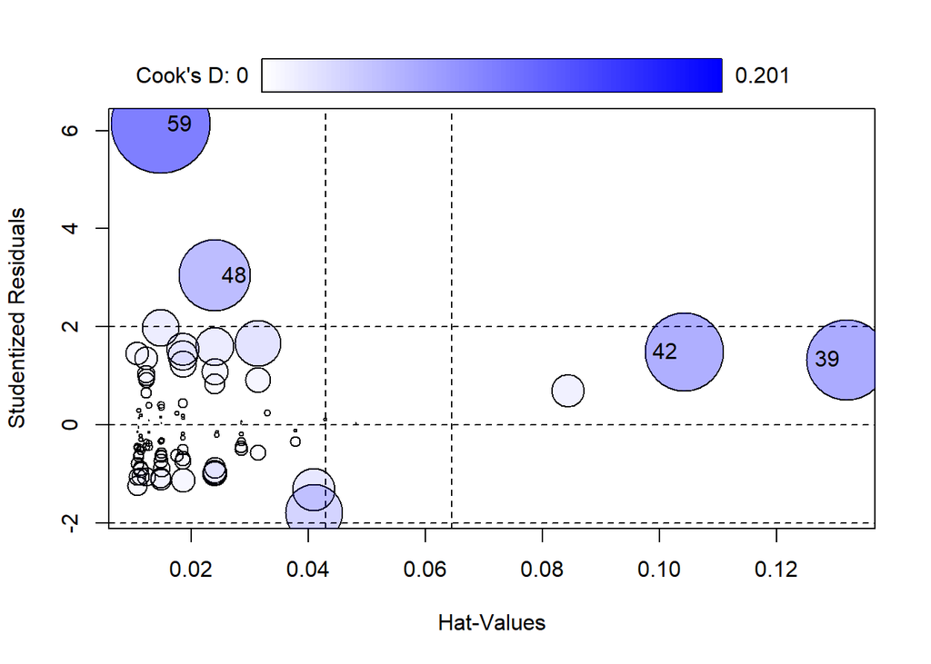

```
##     StudRes        Hat     CookD
## 39 1.329502 0.13196236 0.1332329
## 42 1.484131 0.10426018 0.1265171
## 48 3.038635 0.02406486 0.1043935
## 59 6.128961 0.01479576 0.2012183
```

```r
influencePlot(regre)
```

```r
summary(influence.measures(regre))
```

```
## Potentially influential observations of
##   lm(formula = Price ~ log((1/(MPG.city))), data = cars) :
##
##    dfb.1_ dfb.l((1 dffit   cov.r   cook.d hat
## 39 -0.48  -0.50     0.52_*  1.13_*  0.13   0.13_*
## 42 -0.47  -0.48     0.51_*  1.09_*  0.13   0.10_*
## 48  0.38   0.35     0.48_*  0.86_*  0.10   0.02
## 59  0.44   0.39     0.75_*  0.52_*  0.20   0.01
## 80 -0.01  -0.01     0.01    1.07_*  0.00   0.05
## 83 -0.19  -0.20     0.21    1.10_*  0.02   0.08_*
## 84 -0.02  -0.02     0.02    1.07_*  0.00   0.04
```

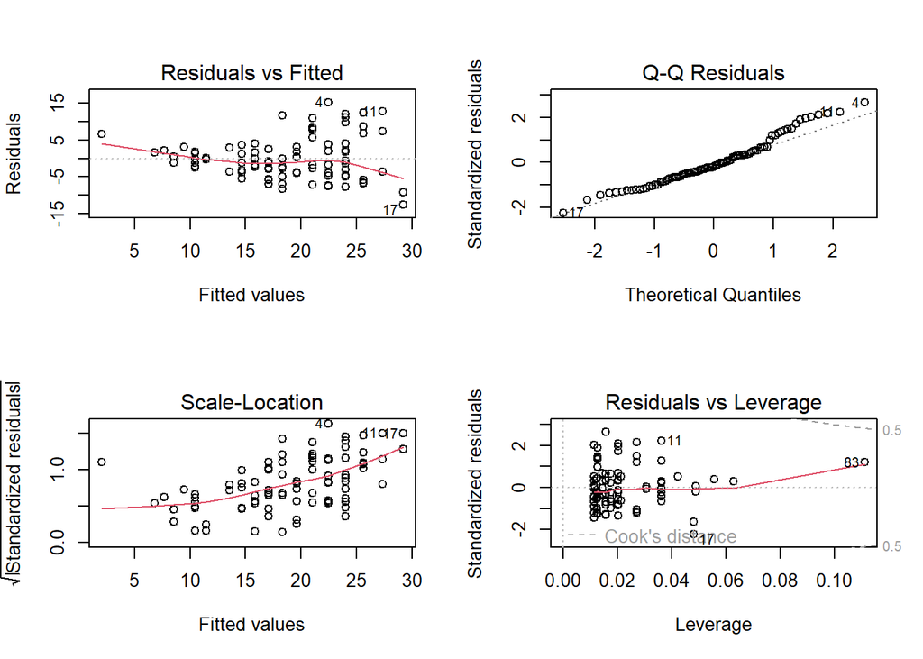

```r
lm1_sinInfl<-update(regre, data=cars[setdiff(rownames(cars),c("42","39","48","59")),])
par(mfrow=c(2,2))
plot(lm1_sinInfl)
```

Se explora los resultados del modelo

```r
print("\nModelo con transformación")
```

```
## [1] "\nModelo con transformación"
```

```r
summary(lm1_sinInfl)
```

```
##
## Call:
## lm(formula = Price ~ log((1/(MPG.city))), data = cars[setdiff(rownames(cars),
##     c("42", "39", "48", "59")), ])
##
## Residuals:
##     Min      1Q  Median      3Q     Max
## -12.603  -3.775  -1.157   2.941  15.220
##
## Coefficients:
##                     Estimate Std. Error t value Pr(>|t|)
## (Intercept)          106.220      9.480  11.204  < 2e-16 ***
## log((1/(MPG.city)))   28.440      3.082   9.228 1.53e-14 ***
## ---
## Signif. codes:  0 '***' 0.001 '**' 0.01 '*' 0.05 '.' 0.1 ' ' 1
##
## Residual standard error: 5.79 on 87 degrees of freedom
## Multiple R-squared:  0.4946, Adjusted R-squared:  0.4888
## F-statistic: 85.15 on 1 and 87 DF,  p-value: 1.534e-14
```

Este modelo, como era de esperar, es mas explicatuvo para el subconjunto de datos que no contienen los outliers. Estudiamos si, con las transformaciones dadas los errores se distribuyen de forma normal

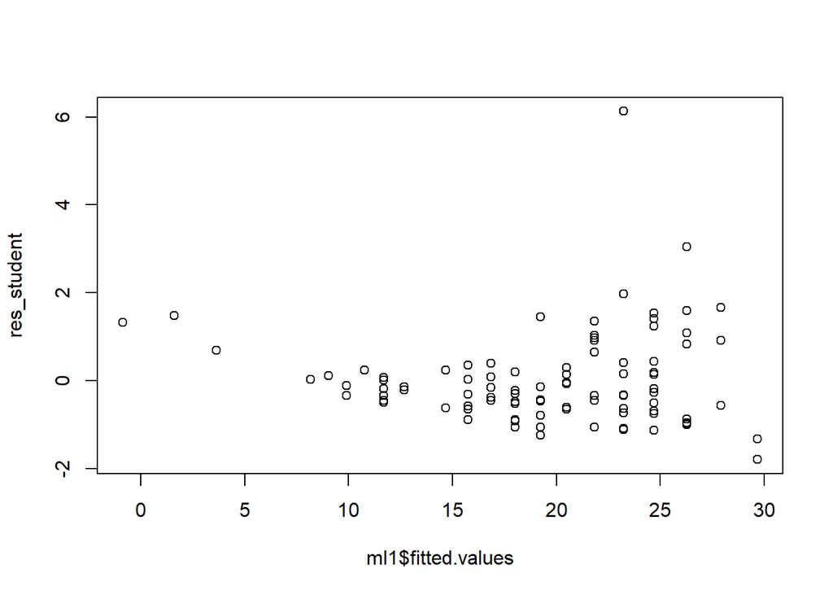

```r
ml1 <- lm(Price ~ log((1/(MPG.city))), data= cars)
res_estandar <- rstandard(ml1)
res_student <- rstudent(ml1)
plot(ml1$fitted.values,res_student)
```

```r
library(MASS)
ajuste_vol <- lm(Price ~ MPG.city,
data = cars)
boxcox(ajuste_vol, lambda = seq(-2,2, length = 10))


b<-boxcox(ajuste_vol, lambda = seq(-2,2, length = 10))
```

[figure not shown]

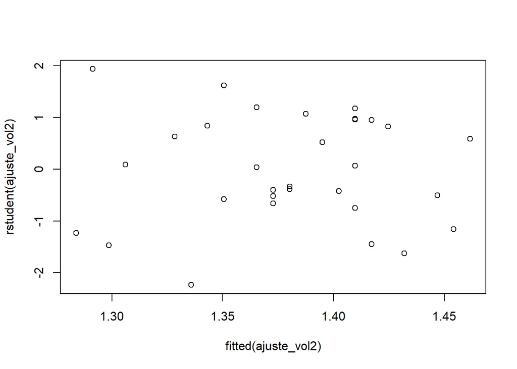

```r
lambda <- b$x[which.max(b$y)]
ajuste_vol2 <- lm(I((Volume^lambda-1)/lambda) ~ Height, data = trees)
plot(fitted(ajuste_vol2), rstudent(ajuste_vol2))
```

```r
#bptest(ajuste_vol2)
```

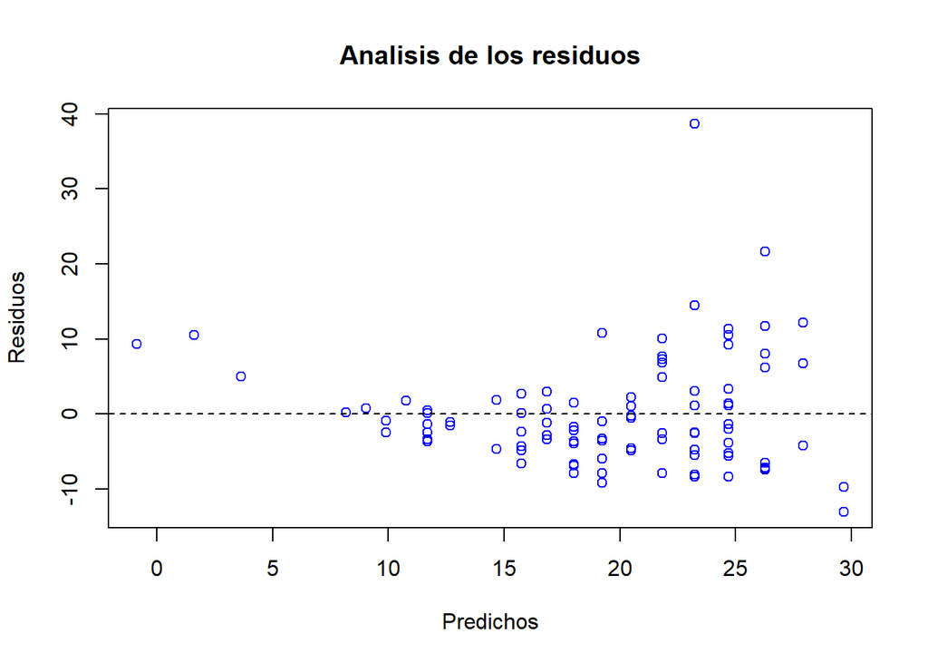

```r
plot(regre$fitted.values,regre$residuals, col='BLUE',
     xlab = 'Predichos',ylab = 'Residuos', main = 'Analisis de los residuos')
abline(h=0,lty=2)
```

```r
library(lmtest)
bptest(regre)
```

```
##
##  studentized Breusch-Pagan test
##
## data:  regre
## BP = 2.7536, df = 1, p-value = 0.09704
```

```r
bptest(reg)
```

```
##
##  studentized Breusch-Pagan test
##
## data:  reg
## BP = 0.97264, df = 1, p-value = 0.324
```

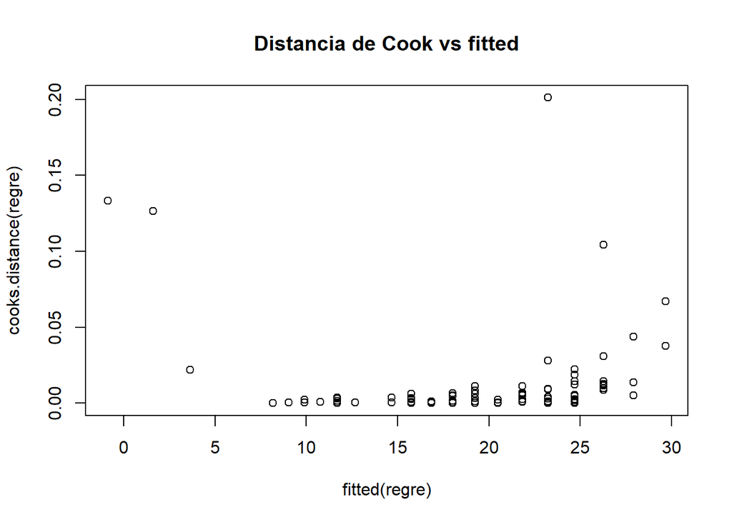

```r
plot(fitted(regre),cooks.distance(regre),main="Distancia de Cook vs fitted")
abline(h=1,col="red",lwd=1);
```

Una posible solucion seria eliminar outliers de acuerdo con la distancia de cook

```r
  library(car)
  outlierTest(ml1,cutoff=1)
```

```
##    rstudent unadjusted p-value Bonferroni p
## 59 6.128961         2.2990e-08   2.1381e-06
## 48 3.038635         3.1106e-03   2.8928e-01
```

```r
shapiro.test(regre$residuals)
```

```
##
##  Shapiro-Wilk normality test
##
## data:  regre$residuals
## W = 0.86435, p-value = 9.727e-08
```

Se puede observar que con la transformacion aplicada, el error se ve disminuido, que se explicado por el R squared, pero este sigue siendo malo, ya que al tomar valores discretizados, la regresión lineal no es el mejor modelo para aplicar.

- ¿Qué precio mínimo se espera para aquellos coches con un consumo de 12 litros a los 100 km por ciudad? Calcula e interpreta el intervalo de confianza y el de predicción.

Las rectas de los itervalos de predicción y confianza se calculan de la forma

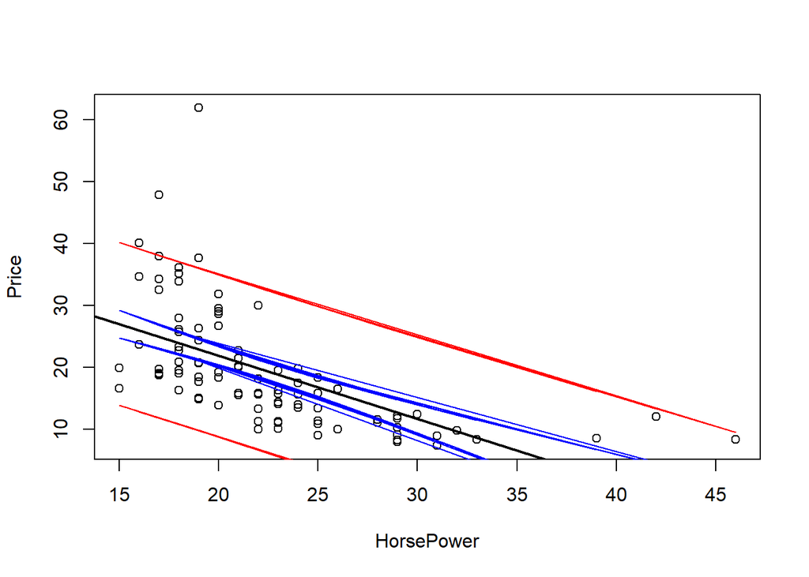

```r
plot(cars$MPG.city,cars$Price,xlab='HorsePower',ylab='Price')
abline(coef = coefficients(reg), lwd=2)
df <- data.frame(list(MPG.city=cars$MPG.city))
bandas <- predict(reg, newdata = df, interval = "confidence",level = 0.9)
lines(cars$MPG.city,bandas[,2],col='BLUE')
lines(cars$MPG.city,bandas[,3],col='BLUE')
bandas2 <- predict(reg, newdata = df, interval = "predict",level = 0.9)
lines(cars$MPG.city,bandas2[,2],col='RED')
lines(cars$MPG.city,bandas2[,3],col='RED')
```

```r
df <- data.frame(list(MPG.city=c(12)))
bandas <- predict(reg, newdata = df, interval = "confidence",level = 0.9)
bandas2 <- predict(reg, newdata = df, interval = "predict",level = 0.9)
```

```r
print(bandas)
```

```
##        fit      lwr      upr
## 1 30.10273 27.26753 32.93792
```

```r
print(bandas2)
```

```
##        fit      lwr      upr
## 1 30.10273 16.81949 43.38596
```

Hay una probabilidad del 90% de que el precio mínimo para los coches se encuentre entre 16.81 y 43.38

## Ejercicio 3

- Considerando un tope de 10 variables, encuentra el número óptimo de variables a incluir en un modelo predictivo de Price, según los criterios R2, BIC y AIC.

```r
library(leaps)
modelos_subset <- regsubsets(Price ~ ., data=cars, nvmax=10)
resumen <- summary(modelos_subset)
summary(modelos_subset)
```

```
## Subset selection object
## Call: regsubsets.formula(Price ~ ., data = cars, nvmax = 10)
## 18 Variables  (and intercept)
##                    Forced in Forced out
## TypeLarge              FALSE      FALSE
## TypeMidsize            FALSE      FALSE
## TypeSmall              FALSE      FALSE
## TypeSporty             FALSE      FALSE
## TypeVan                FALSE      FALSE
## MPG.city               FALSE      FALSE
## MPG.highway            FALSE      FALSE
## EngineSize             FALSE      FALSE
## Horsepower             FALSE      FALSE
## RPM                    FALSE      FALSE
## Rev.per.mile           FALSE      FALSE
## Fuel.tank.capacity     FALSE      FALSE
## Passengers             FALSE      FALSE
## Length                 FALSE      FALSE
## Wheelbase              FALSE      FALSE
## Width                  FALSE      FALSE
## Weight                 FALSE      FALSE
## OriginUSA              FALSE      FALSE
## 1 subsets of each size up to 10
## Selection Algorithm: exhaustive
##           TypeLarge TypeMidsize TypeSmall TypeSporty TypeVan MPG.city
## 1  ( 1 )  " "       " "         " "       " "        " "     " "
## 2  ( 1 )  " "       "*"         " "       " "        " "     " "
## 3  ( 1 )  " "       " "         " "       " "        " "     " "
## 4  ( 1 )  " "       "*"         " "       " "        " "     " "
## 5  ( 1 )  " "       "*"         " "       " "        " "     " "
## 6  ( 1 )  " "       "*"         " "       " "        " "     " "
## 7  ( 1 )  " "       "*"         " "       "*"        " "     " "
## 8  ( 1 )  " "       "*"         " "       "*"        "*"     " "
## 9  ( 1 )  " "       "*"         " "       "*"        "*"     " "
## 10  ( 1 ) " "       "*"         " "       "*"        "*"     " "
##           MPG.highway EngineSize Horsepower RPM Rev.per.mile Fuel.tank.capacity
## 1  ( 1 )  " "         " "        "*"        " " " "          " "
## 2  ( 1 )  " "         " "        "*"        " " " "          " "
## 3  ( 1 )  " "         " "        "*"        " " " "          " "
## 4  ( 1 )  " "         " "        "*"        " " " "          " "
## 5  ( 1 )  " "         " "        "*"        "*" " "          " "
## 6  ( 1 )  " "         " "        "*"        "*" " "          " "
## 7  ( 1 )  " "         " "        "*"        "*" " "          " "
## 8  ( 1 )  " "         " "        "*"        "*" " "          " "
## 9  ( 1 )  "*"         " "        "*"        "*" " "          " "
## 10  ( 1 ) "*"         " "        "*"        "*" "*"          " "
##           Passengers Length Wheelbase Width Weight OriginUSA
## 1  ( 1 )  " "        " "    " "       " "   " "    " "
## 2  ( 1 )  " "        " "    " "       " "   " "    " "
## 3  ( 1 )  " "        " "    "*"       "*"   " "    " "
## 4  ( 1 )  " "        " "    "*"       "*"   " "    " "
## 5  ( 1 )  " "        " "    "*"       "*"   " "    " "
## 6  ( 1 )  " "        " "    "*"       "*"   " "    "*"
## 7  ( 1 )  " "        " "    "*"       "*"   " "    "*"
## 8  ( 1 )  " "        " "    "*"       "*"   " "    "*"
## 9  ( 1 )  " "        " "    "*"       "*"   " "    "*"
## 10  ( 1 ) " "        " "    "*"       "*"   " "    "*"
```

Aqui se pueden ver los mejores modelos por número de parámetros que obtiene los modelos con menor error cuadrático medio.

```r
resultado <- cbind(resumen$rsq,resumen$cp,resumen$bic)
colnames(resultado) <- c('Rsq','Cp','BIC')
resultado
```

```
##             Rsq        Cp       BIC
##  [1,] 0.6212870 34.698727 -81.23561
##  [2,] 0.6656906 22.195204 -88.30122
##  [3,] 0.7006332 12.781933 -94.03557
##  [4,] 0.7212477  8.048629 -96.13815
##  [5,] 0.7367518  4.984548 -96.92759
##  [6,] 0.7515821  2.140541 -97.78758
##  [7,] 0.7572900  2.276161 -95.41679
##  [8,] 0.7620670  2.715864 -92.73285
##  [9,] 0.7649217  3.783436 -89.32280
## [10,] 0.7677334  4.865050 -85.90926
```

El mejor modelo considereando r squared es el de 10 variables. Comparando los C_p de Mallow y el BIC, donde influye el número de parámetros del modelo, se tiene que el mejor es el que usa 6 parámetros.

- ¿Qué variables incluye el modelo obtenido? (seleccionar el criterio que más te guste). Interpreta los coeficientes obtenidos, ¿consideras que tienen sentido?.

```r
coef(modelos_subset, id=6)
```

```
##  (Intercept)  TypeMidsize   Horsepower          RPM    Wheelbase        Width
## 53.053144570  3.553027081  0.168151234 -0.003705075  0.499984355 -1.290071028
##    OriginUSA
## -2.857250508
```

- Selecciona el mejor modelo con el método stepwise.

Ajusto todo con todas las variables posibles para el modelo, y posteriormente le aplico stepwise.

```r
library(ISLR)
modelo_inic <- lm(Price ~ . , data=cars)

traza <- step(modelo_inic, direction = 'both')
```

```
## Start:  AIC=320.75
## Price ~ Type + MPG.city + MPG.highway + EngineSize + Horsepower +
##     RPM + Rev.per.mile + Fuel.tank.capacity + Passengers + Length +
##     Wheelbase + Width + Weight + Origin
##
##                      Df Sum of Sq    RSS    AIC
## - MPG.city            1      0.02 1944.8 318.75
## - Fuel.tank.capacity  1      0.87 1945.6 318.79
## - Type                5    177.26 2122.0 318.86
## - Passengers          1      4.50 1949.3 318.96
## - Length              1      4.91 1949.7 318.98
## - MPG.highway         1      7.64 1952.4 319.11
## - Weight              1     11.31 1956.1 319.29
## - EngineSize          1     16.48 1961.2 319.53
## - Rev.per.mile        1     27.77 1972.5 320.07
## <none>                            1944.8 320.75
## - RPM                 1     67.93 2012.7 321.94
## - Origin              1    136.68 2081.4 325.06
## - Wheelbase           1    193.56 2138.3 327.57
## - Width               1    222.44 2167.2 328.82
## - Horsepower          1    456.18 2400.9 338.34
##
## Step:  AIC=318.75
## Price ~ Type + MPG.highway + EngineSize + Horsepower + RPM +
##     Rev.per.mile + Fuel.tank.capacity + Passengers + Length +
##     Wheelbase + Width + Weight + Origin
##
##                      Df Sum of Sq    RSS    AIC
## - Fuel.tank.capacity  1      0.96 1945.7 316.79
## - Type                5    177.92 2122.7 316.89
## - Passengers          1      4.48 1949.3 316.96
## - Length              1      5.17 1950.0 317.00
## - Weight              1     11.42 1956.2 317.29
## - EngineSize          1     16.64 1961.4 317.54
## - MPG.highway         1     28.19 1973.0 318.09
## - Rev.per.mile        1     30.20 1975.0 318.18
## <none>                            1944.8 318.75
## - RPM                 1     68.76 2013.5 319.98
## + MPG.city            1      0.02 1944.8 320.75
## - Origin              1    136.88 2081.7 323.07
```

[output cut: 135 more lines]

```
## <none>                            2244.0 310.06
## + Type                5    214.12 2029.9 310.73
## - Length              1     66.01 2310.0 310.76
## + Rev.per.mile        1     25.19 2218.9 311.01
## + Passengers          1     19.55 2224.5 311.25
## + MPG.highway         1     16.35 2227.7 311.38
## + MPG.city            1     14.91 2229.1 311.44
## + Fuel.tank.capacity  1      3.38 2240.7 311.92
## + Weight              1      3.31 2240.7 311.92
## + EngineSize          1      0.26 2243.8 312.05
## - Origin              1    165.64 2409.7 314.68
## - RPM                 1    182.27 2426.3 315.32
## - Wheelbase           1    235.98 2480.0 317.36
## - Width               1    475.49 2719.5 325.93
## - Horsepower          1   2791.71 5035.8 383.23
```

```r
modelo_inic <- lm(Price ~ 1 , data=cars)

traza <- step(modelo_inic, Price ~ Type + Horsepower + Width  +
                Wheelbase + RPM + Origin + EngineSize + Weight +
                Fuel.tank.capacity + MPG.city  + MPG.highway+ +Passengers+
                Rev.per.mile+Length ,direction = 'forward')
```

```
## Start:  AIC=422.83
## Price ~ 1
##
##                      Df Sum of Sq    RSS    AIC
## + Horsepower          1    5333.1 3250.9 334.53
## + Weight              1    3595.3 4988.7 374.36
## + Fuel.tank.capacity  1    3294.2 5289.9 379.81
## + EngineSize          1    3063.8 5520.2 383.77
## + MPG.city            1    3034.5 5549.5 384.26
## + Type                5    3421.4 5162.6 385.54
## + MPG.highway         1    2698.5 5885.5 389.73
## + Length              1    2177.3 6406.8 397.62
## + Wheelbase           1    2153.4 6430.6 397.97
## + Width               1    1785.1 6798.9 403.15
## + Rev.per.mile        1    1560.7 7023.3 406.17
## <none>                            8584.0 422.83
## + Origin              1      87.1 8497.0 423.88
## + Passengers          1      28.7 8555.3 424.52
## + RPM                 1       0.2 8583.8 424.83
##
## Step:  AIC=334.53
## Price ~ Horsepower
##
##                      Df Sum of Sq    RSS    AIC
## + Type                5    492.81 2758.1 329.24
## + Origin              1    216.57 3034.3 330.12
## + Wheelbase           1    154.32 3096.6 332.01
## + Weight              1     79.47 3171.4 334.23
## + MPG.highway         1     73.64 3177.2 334.40
## <none>                            3250.9 334.53
## + MPG.city            1     64.97 3185.9 334.65
## + Fuel.tank.capacity  1     59.41 3191.5 334.81
## + Length              1     59.40 3191.5 334.81
## + Width               1     39.56 3211.3 335.39
## + Rev.per.mile        1     29.37 3221.5 335.69
## + Passengers          1     21.94 3228.9 335.90
## + RPM                 1      9.86 3241.0 336.25
## + EngineSize          1      7.67 3243.2 336.31
##
## Step:  AIC=329.24
```

[output cut: 63 more lines]

```
## + Rev.per.mile        1     0.379 2216.0 316.89
##
## Step:  AIC=309.04
## Price ~ Horsepower + Type + Origin + Wheelbase + Width + RPM
##
##                      Df Sum of Sq    RSS    AIC
## <none>                            2036.6 309.04
## + MPG.highway         1   28.3394 2008.2 309.73
## + Rev.per.mile        1   19.0310 2017.5 310.16
## + MPG.city            1   17.1822 2019.4 310.25
## + Passengers          1   16.6019 2020.0 310.28
## + Fuel.tank.capacity  1   13.1444 2023.4 310.44
## + EngineSize          1    8.3422 2028.2 310.65
## + Length              1    6.6389 2029.9 310.73
## + Weight              1    0.0983 2036.5 311.03
```

- Selecciona el mejor modelo con el método stepwise considerando la variable Passengers como factor. Contesta a las siguientes preguntas:

```r
modelo_inic <- lm(Price ~ 1 , data=cars)

traza <- step(modelo_inic, Price ~ Type + Horsepower + Width  +
                Wheelbase + RPM + Origin + EngineSize + Weight +
                Fuel.tank.capacity + MPG.city  + MPG.highway+ + as.factor(Passengers)+
                Rev.per.mile+Length ,direction = 'forward')
```

```
## Start:  AIC=422.83
## Price ~ 1
##
##                         Df Sum of Sq    RSS    AIC
## + Horsepower             1    5333.1 3250.9 334.53
## + Weight                 1    3595.3 4988.7 374.36
## + Fuel.tank.capacity     1    3294.2 5289.9 379.81
## + EngineSize             1    3063.8 5520.2 383.77
## + MPG.city               1    3034.5 5549.5 384.26
## + Type                   5    3421.4 5162.6 385.54
## + MPG.highway            1    2698.5 5885.5 389.73
## + Length                 1    2177.3 6406.8 397.62
## + Wheelbase              1    2153.4 6430.6 397.97
## + Width                  1    1785.1 6798.9 403.15
## + Rev.per.mile           1    1560.7 7023.3 406.17
## + as.factor(Passengers)  5    1116.6 7467.4 419.87
## <none>                               8584.0 422.83
## + Origin                 1      87.1 8497.0 423.88
## + RPM                    1       0.2 8583.8 424.83
##
## Step:  AIC=334.53
## Price ~ Horsepower
##
##                         Df Sum of Sq    RSS    AIC
## + Type                   5    492.81 2758.1 329.24
## + Origin                 1    216.57 3034.3 330.12
## + Wheelbase              1    154.32 3096.6 332.01
## + Weight                 1     79.47 3171.4 334.23
## + MPG.highway            1     73.64 3177.2 334.40
## <none>                               3250.9 334.53
## + MPG.city               1     64.97 3185.9 334.65
## + Fuel.tank.capacity     1     59.41 3191.5 334.81
## + Length                 1     59.40 3191.5 334.81
## + Width                  1     39.56 3211.3 335.39
## + Rev.per.mile           1     29.37 3221.5 335.69
## + RPM                    1      9.86 3241.0 336.25
## + EngineSize             1      7.67 3243.2 336.31
## + as.factor(Passengers)  5    147.15 3103.7 340.22
##
## Step:  AIC=329.24
```

[output cut: 63 more lines]

```
## + as.factor(Passengers)  4    90.847 2125.6 319.02
##
## Step:  AIC=309.04
## Price ~ Horsepower + Type + Origin + Wheelbase + Width + RPM
##
##                         Df Sum of Sq    RSS    AIC
## <none>                               2036.6 309.04
## + MPG.highway            1    28.339 2008.2 309.73
## + Rev.per.mile           1    19.031 2017.5 310.16
## + MPG.city               1    17.182 2019.4 310.25
## + Fuel.tank.capacity     1    13.144 2023.4 310.44
## + EngineSize             1     8.342 2028.2 310.65
## + Length                 1     6.639 2029.9 310.73
## + Weight                 1     0.098 2036.5 311.03
## + as.factor(Passengers)  4    80.824 1955.7 313.27
```

- ¿Qué% de la varianza de Price explica el modelo?

```r
modelo <- lm(Price ~  Type + Horsepower + Width  +
                Wheelbase + RPM + Origin ,data=cars)
summary(modelo)
```

```
##
## Call:
## lm(formula = Price ~ Type + Horsepower + Width + Wheelbase +
##     RPM + Origin, data = cars)
##
## Residuals:
##      Min       1Q   Median       3Q      Max
## -11.2403  -2.6302  -0.1117   2.0195  22.6970
##
## Coefficients:
##              Estimate Std. Error t value Pr(>|t|)
## (Intercept) 46.649677  27.321819   1.707 0.091529 .
## TypeLarge    1.299684   2.914914   0.446 0.656864
## TypeMidsize  3.961813   1.914233   2.070 0.041632 *
## TypeSmall    0.334407   2.088371   0.160 0.873174
## TypeSporty   3.015877   2.299341   1.312 0.193307
## TypeVan     -1.849234   2.874896  -0.643 0.521866
## Horsepower   0.160788   0.017971   8.947 9.17e-14 ***
## Width       -1.434571   0.388931  -3.688 0.000404 ***
## Wheelbase    0.663732   0.212168   3.128 0.002434 **
## RPM         -0.003695   0.001373  -2.691 0.008630 **
## OriginUSA   -3.217185   1.296097  -2.482 0.015098 *
## ---
## Signif. codes:  0 '***' 0.001 '**' 0.01 '*' 0.05 '.' 0.1 ' ' 1
##
## Residual standard error: 4.984 on 82 degrees of freedom
## Multiple R-squared:  0.7627, Adjusted R-squared:  0.7338
## F-statistic: 26.36 on 10 and 82 DF,  p-value: < 2.2e-16
```

Es capaz de explicar el 76% de la variabilidad de Price

- ¿Podrías depurar el modelo?

En este caso, parece que la variable Type no es muy util, al tener solo una de sus categorias entre las significativas. Es por ello que, para nuestra depuración del modelo, decidimos eliminarla.

```r
modelo <- lm(Price ~    Horsepower + Width  +
                Wheelbase + RPM + Origin ,data=cars)
summary(modelo)
```

```
##
## Call:
## lm(formula = Price ~ Horsepower + Width + Wheelbase + RPM + Origin,
##     data = cars)
##
## Residuals:
##     Min      1Q  Median      3Q     Max
## -9.5177 -2.9775 -0.3315  2.1914 24.5784
##
## Coefficients:
##              Estimate Std. Error t value Pr(>|t|)
## (Intercept) 50.547305  22.999585   2.198 0.030623 *
## Horsepower   0.176844   0.016879  10.477  < 2e-16 ***
## Width       -1.403926   0.355122  -3.953 0.000157 ***
## Wheelbase    0.590177   0.136396   4.327 4.02e-05 ***
## RPM         -0.003573   0.001374  -2.600 0.010939 *
## OriginUSA   -3.011577   1.303541  -2.310 0.023238 *
## ---
## Signif. codes:  0 '***' 0.001 '**' 0.01 '*' 0.05 '.' 0.1 ' ' 1
##
## Residual standard error: 5.153 on 87 degrees of freedom
## Multiple R-squared:  0.7309, Adjusted R-squared:  0.7154
## F-statistic: 47.26 on 5 and 87 DF,  p-value: < 2.2e-16
```

Vemos que con este cambio, el r squared no se ve demasiado decrementado.

- ¿Cuál es el efecto de la variable Origin sobre Price?

```r
reg <- lm(Price ~ Origin, data=cars)

summary(reg)
```

```
##
## Call:
## lm(formula = Price ~ Origin, data = cars)
##
## Residuals:
##     Min      1Q  Median      3Q     Max
## -12.509  -7.173  -2.109   2.791  41.391
##
## Coefficients:
##             Estimate Std. Error t value Pr(>|t|)
## (Intercept)   20.509      1.440  14.238   <2e-16 ***
## OriginUSA     -1.936      2.005  -0.966    0.337
## ---
## Signif. codes:  0 '***' 0.001 '**' 0.01 '*' 0.05 '.' 0.1 ' ' 1
##
## Residual standard error: 9.663 on 91 degrees of freedom
## Multiple R-squared:  0.01014,    Adjusted R-squared:  -0.0007366
## F-statistic: 0.9323 on 1 and 91 DF,  p-value: 0.3368
```

Por si sola, la variable origin no es capaz de explicar la variable Price, al no ser muy significativo el valor de OriginUSA

- ¿Qué modelo de los apartados anteriores es mejor? Con el que te quedes, realiza el diagnóstico de tu modelo, sin emprender ninguna acción, e indica los problemas que presenta.

En este caso nos quedamos con el modelo obtenido por stepwise forward

```r
modelo <- lm(Price ~  Type + Horsepower + Width  +
                Wheelbase + RPM + Origin ,data=cars)
summary(modelo)
```

```
##
## Call:
## lm(formula = Price ~ Type + Horsepower + Width + Wheelbase +
##     RPM + Origin, data = cars)
##
## Residuals:
##      Min       1Q   Median       3Q      Max
## -11.2403  -2.6302  -0.1117   2.0195  22.6970
##
## Coefficients:
##              Estimate Std. Error t value Pr(>|t|)
## (Intercept) 46.649677  27.321819   1.707 0.091529 .
## TypeLarge    1.299684   2.914914   0.446 0.656864
## TypeMidsize  3.961813   1.914233   2.070 0.041632 *
## TypeSmall    0.334407   2.088371   0.160 0.873174
## TypeSporty   3.015877   2.299341   1.312 0.193307
## TypeVan     -1.849234   2.874896  -0.643 0.521866
## Horsepower   0.160788   0.017971   8.947 9.17e-14 ***
## Width       -1.434571   0.388931  -3.688 0.000404 ***
## Wheelbase    0.663732   0.212168   3.128 0.002434 **
## RPM         -0.003695   0.001373  -2.691 0.008630 **
## OriginUSA   -3.217185   1.296097  -2.482 0.015098 *
## ---
## Signif. codes:  0 '***' 0.001 '**' 0.01 '*' 0.05 '.' 0.1 ' ' 1
##
## Residual standard error: 4.984 on 82 degrees of freedom
## Multiple R-squared:  0.7627, Adjusted R-squared:  0.7338
## F-statistic: 26.36 on 10 and 82 DF,  p-value: < 2.2e-16
```

- Emprende ahora las acciones que te parezcan oportunas e indica los problemas que has conseguido solucionar o mejorar un poco.

De cara a mejorarlo, decidimos probar y unificar las categorias de type que no son significativas, de tal forma que queda un factor que contiene TypeMid y TypeNotMid.

```r
library(dplyr)
midsize <- cars$Type=="Midsize"
cars_mod <- cars %>%
  mutate(Type = if_else(midsize, "Midsize", "notMidsize"))%>%
  mutate(Type = as.factor(Type))
```

```r
modelo <- lm(Price ~  Type + Horsepower + Width  +
                Wheelbase + RPM + Origin ,data=cars_mod)
summary(modelo)
```

```
##
## Call:
## lm(formula = Price ~ Type + Horsepower + Width + Wheelbase +
##     RPM + Origin, data = cars_mod)
##
## Residuals:
##      Min       1Q   Median       3Q      Max
## -11.4670  -2.4196  -0.2303   1.9266  23.1995
##
## Coefficients:
##                 Estimate Std. Error t value Pr(>|t|)
## (Intercept)    56.606172  22.340744   2.534 0.013097 *
## TypenotMidsize -3.553027   1.327499  -2.676 0.008908 **
## Horsepower      0.168151   0.016631  10.111 2.72e-16 ***
## Width          -1.290071   0.345800  -3.731 0.000342 ***
## Wheelbase       0.499984   0.136046   3.675 0.000413 ***
## RPM            -0.003705   0.001329  -2.789 0.006513 **
## OriginUSA      -2.857251   1.261002  -2.266 0.025971 *
## ---
## Signif. codes:  0 '***' 0.001 '**' 0.01 '*' 0.05 '.' 0.1 ' ' 1
##
## Residual standard error: 4.98 on 86 degrees of freedom
## Multiple R-squared:  0.7516, Adjusted R-squared:  0.7343
## F-statistic: 43.37 on 6 and 86 DF,  p-value: < 2.2e-16
```

Mejora el r squared ajustado, ya que utiliza menos categorias en la variable categorica sin perder casi información. Además, se peude observar que todas las variables del modelo tomado son significativas.

Por último, visualizamos los outliers de los datos para el modelo

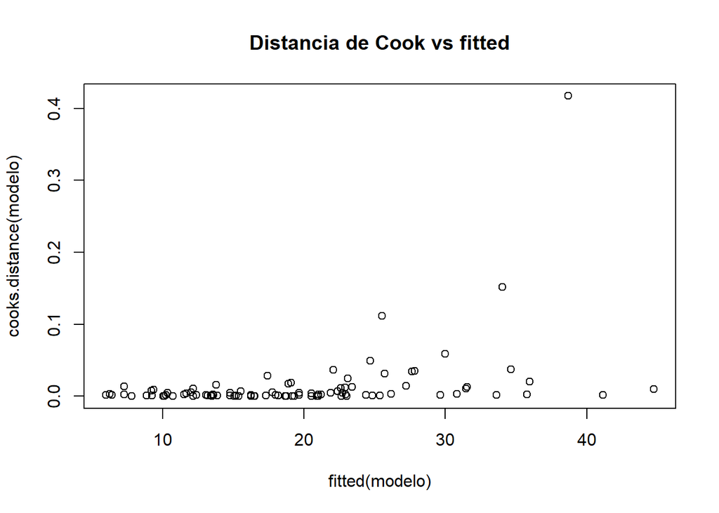

```r
# Cook

plot(fitted(modelo),cooks.distance(modelo),main="Distancia de Cook vs fitted")
```

Se puede observar que, usando cook solo encontramos una muestra que se puede considerar outlier

Respecto a la colinealidad del modelo, utilizamos VIF

```r
library(car)
library(rms)
rms::vif(modelo)
```

```
## TypenotMidsize     Horsepower          Width      Wheelbase            RPM
##       1.193688       2.815159       6.335986       3.193847       2.332075
##      OriginUSA
##       1.489453
```

- Obtén la predicción del precio para un coche en la mediana de los predictores en el modelo escogido. Notar que las variables categóricas se tratan de diferente manera, no hay mediana.